# numerki 4

```python
import time
import numpy as np
import matplotlib.pyplot as plt
N = 80
np.set_printoptions(precision=15, suppress=True)
time_list = []
x_list = []
N_list = []
time_b_list = []
result_b_list = []
def moja_piekna_funckja(N, razy, rozmiar):
    while(N<=80*rozmiar):
        r = 0
        wynik = 0.0
        #####################
        #wynik_b = 0.0
        result = 0.0
        #while(r<razy):
        #A_b = np.zeros((N, N))
        #wektor_b = [5.0] * N
        #########################################################
        #--------------BIBLIOTECZNA METODA--------------------------------------------
        #for i in range(N):
        #    for j in range(N):
        #        if (i == j):
        #            A_b[i][j] = 12
        #        elif (j == i + 1):
        #            A_b[i][j] = 8
        #        else:
        #            A_b[i][j] = 1
        #start_b = time.time()
        #result = np.linalg.solve(A_b, wektor_b)
        #stop_b = time.time() - start_b
        #wynik_b +=stop_b
        while(r<razy):
        #--------------METODA WLASNA--------------------------------------------------
            x = y = z = np.zeros(N)
            Ann = 11.0
            Ann1 = 7.0
            b = 5.0
            start = time.time()
            z[len(z)-1] = b/Ann
            y[len(z)-1] = 1/Ann
            for i in range(N-2, -1, -1):
                z[i] = (b - z[i+1]*Ann1)/Ann
                y[i] = (1 - y[i+1]*Ann1)/Ann

            skalar = sum(z)/(1+sum(y))

            for i in range(N):
                x[i] = (z[i] - skalar*y[i])*b
                #print(x)
            stop = time.time() - start
            r+=1
            wynik+=stop
        #----------------------------------------------------------------------------

        wynik /=razy
        #wynik_b /= razy

        ##################################
        #result_b_list.append(result)
        #time_b_list.append(wynik_b)
        ##################################
        N_list.append(N)
        N += 100
        time_list.append(wynik)
        x_list.append(x)

    print("Wynik metoda wlasna: \n")
    print(x_list[0])
    ##########################################################
    #print("Wynik metoda biblioteczna: \n")
    #print(result_b_list[0])
    ##########################################################
    print("Wynik pomiaru czasu z wlasnej metody: \n")
    print(time_list[0])
    ##########################################################
    #print("Wynik pomiaru czasu z metudy bibliotecznej: \n")
    #print(time_b_list[0])
    #########################################################
    plt.plot(np.array(N_list), np.array(time_list))
    #########################################################
    #plt.plot(np.array(N_list), np.array(time_b_list))
    #########################################################


    plt.xlabel("N")
    plt.ylabel("Czas, potrzebny na obliczenie")
    plt.show()
```

Zadanie Numeryczne 4 Sprawodzanie numeryczne

Cel badania Celem badania było sprawdzenie efektywności rozwiązywania układu równań metodą wyznaczenia macierzy A^-1 według wzoru Shermana-Morrisona dla macierzy, mającej wartości 12 i 8 na głownej diagonali i nad diagonała odpowiednio oraz jedynki na pozostawych pozycjach.

Zadanie numeryczne NUM4:

1. Dla zadanej macierzy A i wektora b obliczyć równanie Ay = b, stosując odpowiednią metodę, zaimplementowaną samodzielnie.
2. Sprawdzać wynik należy przy użyciu procedur bibliotecznych lub pakietów algebry komputerowej.
3. Potraktować N jako zmienną i zmierzyć czas potrzebny do uzyskania rozwiązania w funkcji N.
4. 4. Wynik przedstawić na wykresie.

Metoda Badawcza Dla sprawdzania wyników korzystamy z metody bibliotecznej, dla której w sposób standardowy, używajać dwu pętli for tworzymy macierz A i wektor b. Następnie przy użyciu funkcji np.linalg.solve() obliczmy wynik i czas, za który metoda biblioteczna rozwiązuje dane równanie.

W metodzie własnej w sposób jawny nie definiujemy macierz A, bo nie jest to nam potrzebne. Macierz naszą możemy rozłożyć na sumu dwu macierzy, niech ta będą A1 oraz A2. A1 jest to macierz dwudiagonalna , która ma na każdej pozycji głownej diagonali wartość 11 oraz 7 nad głowną diagonalą, pozostałe miejsca wypełnione są zerami. A2 jest wypełniona jedynkami na każdej pozycji. Macierz A2 można zapisać jako iloczyn dwu wektorów, niech to będzie u oraz v^T.

Maicerz A = A1 + u*v^T, u = v. Podstawiając do naszego równania otrzymujemy (A1 + u*v^T, u = v)*y = b

Chcemy więc wyrazić z tego y:

y = ((A1 + u*v^T, u = v)^-1)*b

To z kolei możemy zapisać według wzoru Shermana-Morrisona: A^-1*b = (A^-1*u*v^T*A^-1*b)/(1+v^T*A^-1*u) Niech:

1. A^-1*u = x
2. A^-1*b = z Gdzie x oraz z to jakieś wektory Nx1

Wyniki Korzystanie ze wzory Shermana_Morrisona i odpowiedniego algorytmu spowodowało, że obliczamy następujące równanie w czasie lioniowym O(n), co jest optymicacją czasową i pamięciową, co pokazuje następny wykres. Pomarańczowy wykres jest czaasem odbliczenia za pomocą metody bibliotecznej. Niebieski wykres jest czasem rozwiązywania równania przez własną metodę.

[figure not shown]

Widać z wykresu, że różnica jest tak duża, że niebieski wykres wygląda tak, jakby wcale nie wzrastał, chociaż w rzeczywistości on rośnie, możemy to zobaczyć jeżeli zmiejszymy zakres badania N.

[figure not shown]

Niestabilność pomarańczowego wykresu jest spowodowana działaniem innych programów na komputerze, dlatego dla osiągnięnia idealnych wyników warto korzystać z odpowiednich narzędzi(komputerów). Na tym wykresie liniowy wzrost niebieskiego wykresu już jest zauważalny, a jednak i tak zostaje bardzo mały. Zobaczymy jak on będzie wyglądać bez pomarańczowego wykresu.

[output not shown]

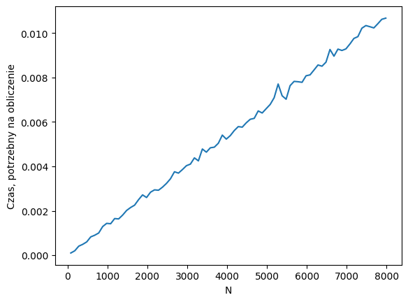

```python
moja_piekna_funckja(80, 20, 100)
```

Teraz dla większej dokładności narysujemy sobie więcej wykerów, co pokaże nam, że przy odpowiedniej ilości powtórzeń wykres będzie zbliżać się do prostej linii. Trzy wykresy

[output not shown]

[figure not shown]

```python
moja_piekna_funckja(80, 40, 100)
```

6 wykresów

[output not shown]

[figure not shown]

```python
moja_piekna_funckja(80, 60, 100)
```

12 wykresów

[output not shown]

[figure not shown]

```python
moja_piekna_funckja(80, 80, 100)
```

Wyniki działania programu

Autor: Maksym Yankovenko.